# R Notebook

This is an attempt to recreate the Data Science homework that I completed 6 years ago. I will be re-doing everything within both R and Python to demonstrate versatility and differences between the two programs.

For this, I will be downloading the UBSprices dataset from the ALR4 package. I will look at the summary statistics first to see fi there any any potential transformations that may be had.

```r
library(alr4)

summary(UBSprices)
```

```
   bigmac2009       bread2009        rice2009       bigmac2003       bread2003       rice2003
 Min.   : 12.00   Min.   : 8.00   Min.   : 8.00   Min.   : 10.00   Min.   : 6.0   Min.   : 5.00
 1st Qu.: 17.25   1st Qu.:13.00   1st Qu.:11.00   1st Qu.: 16.50   1st Qu.:12.0   1st Qu.:12.00
 Median : 25.50   Median :19.00   Median :17.00   Median : 22.00   Median :18.0   Median :16.00
 Mean   : 35.35   Mean   :23.02   Mean   :22.34   Mean   : 36.74   Mean   :21.5   Mean   :19.46
 3rd Qu.: 42.00   3rd Qu.:25.75   3rd Qu.:26.50   3rd Qu.: 47.00   3rd Qu.:25.0   3rd Qu.:22.00
 Max.   :158.00   Max.   :84.00   Max.   :74.50   Max.   :185.00   Max.   :89.0   Max.   :96.00
```

Now looking at the head of the data, we have 6 variables that deal with the prices of items depending on the year and country.

```r
head(UBSprices)
```

|  | bigmac2009 | bread2009 | rice2009 | bigmac2003 | bread2003 | rice2003 |
| --- | --- | --- | --- | --- | --- | --- |
| Amsterdam | 19 | 10 | 11 | 16 | 9 | 9 |
| Athens | 30 | 13 | 27 | 21 | 12 | 19 |
| Auckland | 19 | 19 | 13 | 19 | 19 | 9 |
| Bangkok | 45 | 43 | 27 | 50 | 42 | 25 |
| Barcelona | 21 | 17 | 8 | 22 | 19 | 10 |
| Berlin | 19 | 10 | 17 | 16 | 10 | 16 |

Now to plot bigmac2009 against bigmac2003

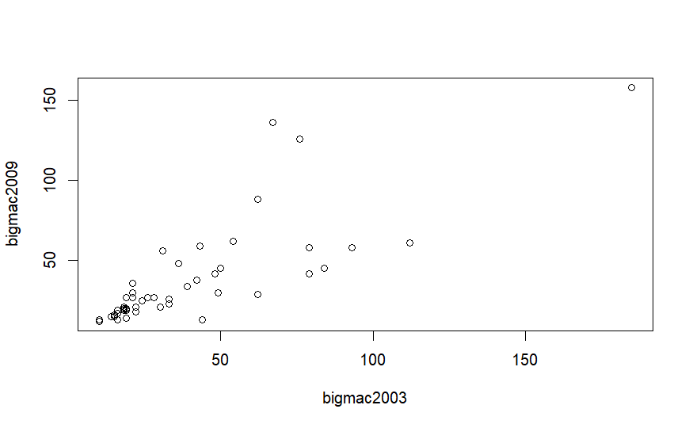

```r
plot(bigmac2009~bigmac2003, data=UBSprices)
```

looking at the plot, there seems to be a significant case of non-constant variance. Not only that, looking back at the summary statistics, we may have ranges that go over more than one order, so we will add log transformation in the predictor variable as well as the resposne. We will fit a regression line in red to see how well it fits the data.

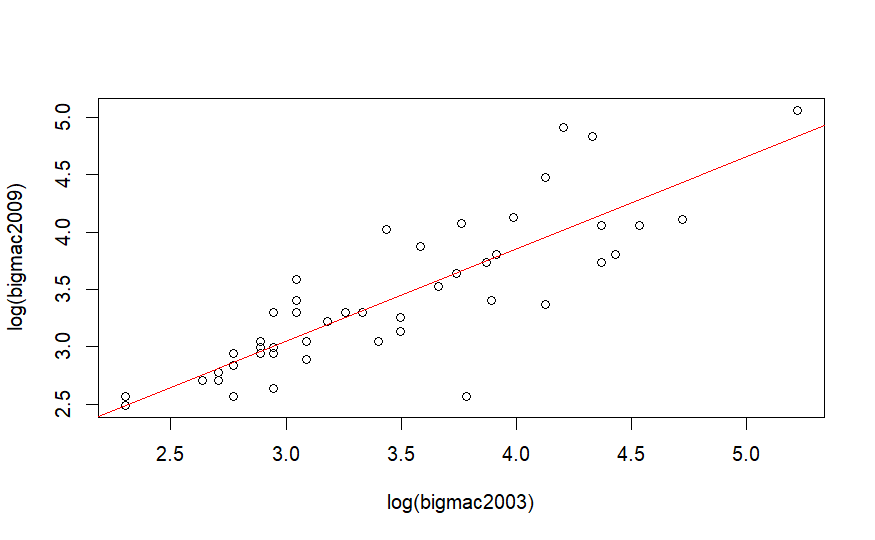

```r
fitline <- lm(log(bigmac2009)~log(bigmac2003), data = UBSprices)
plot(log(bigmac2009)~log(bigmac2003), data=UBSprices)
abline(fitline, col="red")
```

The log transformations seems to have significantly fixed the variances of the data to a more homoscedastic one. The red line from the regression that we fit, seems to fig the data pretty well. Now it is time to read the variable and see what it tells us.

```r
summary(fitline)
```

```
Call:
lm(formula = log(bigmac2009) ~ log(bigmac2003), data = UBSprices)

Residuals:
     Min       1Q   Median       3Q      Max
-1.11379 -0.10663 -0.01378  0.08207  0.89628

Coefficients:
                Estimate Std. Error t value Pr(>|t|)
(Intercept)      0.64031    0.22922   2.793  0.00728 **
log(bigmac2003)  0.80293    0.06709  11.967  < 2e-16 ***
---
Signif. codes:  0 ‘***’ 0.001 ‘**’ 0.01 ‘*’ 0.05 ‘.’ 0.1 ‘ ’ 1

Residual standard error: 0.3324 on 52 degrees of freedom
Multiple R-squared:  0.7336,    Adjusted R-squared:  0.7285
F-statistic: 143.2 on 1 and 52 DF,  p-value: < 2.2e-16
```

For the next problem, we will be looking at the oldfaith data set. We are going to see the relationship between the Interval between eruptions of geysers and if they are related to the Duration of each eruption. First, as always, we will do exploratory data exploration before fitting the model.

```r
head(oldfaith)
```

|  | Duration | Interval |
| --- | --- | --- |
| 1 | 216 | 79 |
| 2 | 108 | 54 |
| 3 | 200 | 74 |
| 4 | 137 | 62 |
| 5 | 272 | 85 |
| 6 | 173 | 55 |

```r
NA
```

We see we only have two variables, Now let’s look at the summary statistics to see if there are any possible transformations we need to perform.

```r
summary(oldfaith)
```

```
    Duration        Interval
 Min.   : 96.0   Min.   :43.00
 1st Qu.:130.0   1st Qu.:58.00
 Median :240.0   Median :76.00
 Mean   :209.9   Mean   :71.11
 3rd Qu.:267.8   3rd Qu.:82.00
 Max.   :306.0   Max.   :96.00
```

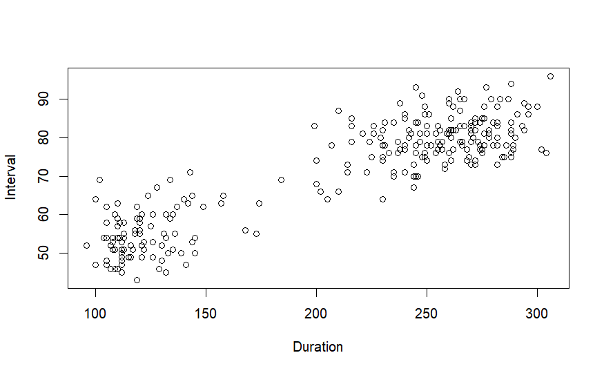

```r
plot(oldfaith$Duration, oldfaith$Interval, xlab= "Duration", ylab="Interval")
```

```r
oldfaithmodel <- lm(Interval~Duration, data=oldfaith)
summary(oldfaithmodel)
```

```
Call:
lm(formula = Interval ~ Duration, data = oldfaith)

Residuals:
     Min       1Q   Median       3Q      Max
-12.3337  -4.5250   0.0612   3.7683  16.9722

Coefficients:
             Estimate Std. Error t value Pr(>|t|)
(Intercept) 33.987808   1.181217   28.77   <2e-16 ***
Duration     0.176863   0.005352   33.05   <2e-16 ***
---
Signif. codes:  0 ‘***’ 0.001 ‘**’ 0.01 ‘*’ 0.05 ‘.’ 0.1 ‘ ’ 1

Residual standard error: 6.004 on 268 degrees of freedom
Multiple R-squared:  0.8029,    Adjusted R-squared:  0.8022
F-statistic:  1092 on 1 and 268 DF,  p-value: < 2.2e-16
```

```r
datapred <- predict(oldfaithmodel, newdata=data.frame(Duration=250), interval="prediction", se.fit=TRUE)
datapred
```

```
$fit
       fit      lwr      upr
1 78.20354 66.35401 90.05307

$se.fit
[1] 0.4237971

$df
[1] 268

$residual.scale
[1] 6.00355
```

Here we can see that the interval is between 66.35 and 90.05 with the prediction at 78.203. Now lets do a prediction within the confines of the mean model itself.

```r
grid <- seq(0, 300, 1)

plot(oldfaith$Duration, oldfaith$Interval, xlab="Duration", ylab="Interval")
abline(oldfaithmodel, col="red")
```

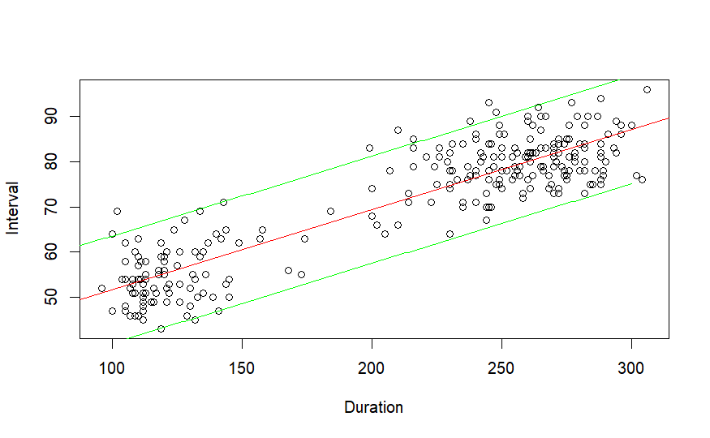

```r
lines(x=grid, y=predict(oldfaithmodel, newdata=data.frame(Duration=grid), interval="prediction")[,2], col="green")
lines(x=grid, y=predict(oldfaithmodel, newdata=data.frame(Duration=grid), interval="prediction")[,3], col="green")
```

```r
NA
NA
```

```r
predict(oldfaithmodel, newdata=data.frame(Duration=250), interval = "confidence", se.fit=TRUE)
```

```
$fit
       fit      lwr      upr
1 78.20354 77.36915 79.03794

$se.fit
[1] 0.4237971

$df
[1] 268

$residual.scale
[1] 6.00355
```

```r
grid2 <- seq(0, 300, 1)
plot(oldfaith$Duration, oldfaith$Interval, xlab="Duration", ylab="Interval")
abline(oldfaithmodel, col="red")
```

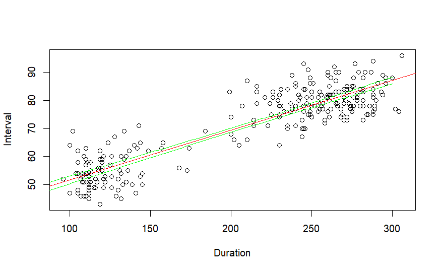

```r
lines(x=grid2, y=predict(oldfaithmodel, newdata=data.frame(Duration=grid2), interval="confidence")[,2], col="green")
lines(x=grid2, y=predict(oldfaithmodel, newdata=data.frame(Duration=grid2), interval="confidence")[,3], col="green")
```

For our next problem, we will be looking at UN data to look at fertility as the response to a linear relationship. Fertility, in this context, is the amount of children per woman. We will also be using ppgd in log form as well as the percent of urban area ina society.

```r
head(UN11)
```

|  | region | group | fertility | ppgdp | lifeExpF | pctUrban |
| --- | --- | --- | --- | --- | --- | --- |
| Afghanistan | Asia | other | 5.968 | 499.0 | 49.49 | 23 |
| Albania | Europe | other | 1.525 | 3677.2 | 80.40 | 53 |
| Algeria | Africa | africa | 2.142 | 4473.0 | 75.00 | 67 |
| Angola | Africa | africa | 5.135 | 4321.9 | 53.17 | 59 |
| Anguilla | Caribbean | other | 2.000 | 13750.1 | 81.10 | 100 |
| Argentina | Latin Amer | other | 2.172 | 9162.1 | 79.89 | 93 |

```r
summary(UN11)
```

```
        region      group       fertility         ppgdp             lifeExpF        pctUrban
 Africa    :53   oecd  : 31   Min.   :1.134   Min.   :   114.8   Min.   :48.11   Min.   : 11.00
 Asia      :50   other :115   1st Qu.:1.754   1st Qu.:  1283.0   1st Qu.:65.66   1st Qu.: 39.00
 Europe    :39   africa: 53   Median :2.262   Median :  4684.5   Median :75.89   Median : 59.00
 Latin Amer:20                Mean   :2.761   Mean   : 13012.0   Mean   :72.29   Mean   : 57.93
 Caribbean :17                3rd Qu.:3.545   3rd Qu.: 15520.5   3rd Qu.:79.58   3rd Qu.: 75.00
 Oceania   :17                Max.   :6.925   Max.   :105095.4   Max.   :87.12   Max.   :100.00
 (Other)   : 3
```

Just looking at the variables we have, we can already see that ppgdp will cause us problems if we do not transform for it as it goes over several orders.

```r
fertilityfit <- lm(fertility~log(ppgdp)+pctUrban, data=UN11)
summary(fertilityfit)
```

```
Call:
lm(formula = fertility ~ log(ppgdp) + pctUrban, data = UN11)

Residuals:
     Min       1Q   Median       3Q      Max
-2.15114 -0.64929 -0.06604  0.63253  2.99102

Coefficients:
              Estimate Std. Error t value Pr(>|t|)
(Intercept)  7.9932699  0.3993367  20.016   <2e-16 ***
log(ppgdp)  -0.6151425  0.0641565  -9.588   <2e-16 ***
pctUrban    -0.0004393  0.0042656  -0.103    0.918
---
Signif. codes:  0 ‘***’ 0.001 ‘**’ 0.01 ‘*’ 0.05 ‘.’ 0.1 ‘ ’ 1

Residual standard error: 0.9328 on 196 degrees of freedom
Multiple R-squared:   0.52, Adjusted R-squared:  0.5151
F-statistic: 106.2 on 2 and 196 DF,  p-value: < 2.2e-16
```

Looking at the coefficients of the model that we have fit, it seems as if the the log of ppgdp is significant, where else the p value for pctUrban shows that it is not significant. Both show negative relationships to the response variable as well. For the log of ppggd, it tells us that for a 1% increase in the log of ppgd associates with a decrease of .00615 in the fertility per woman. If the pctUrban amounted to anything, it would say that for every unit increase of the pctUrban variable results in a decrease of .00044 of fertility per woman. Let’s look at the av plots as well to further confirm what the summary is telling us. The avPlots tell us, with all other variables in the model, does this model explain any other variation.

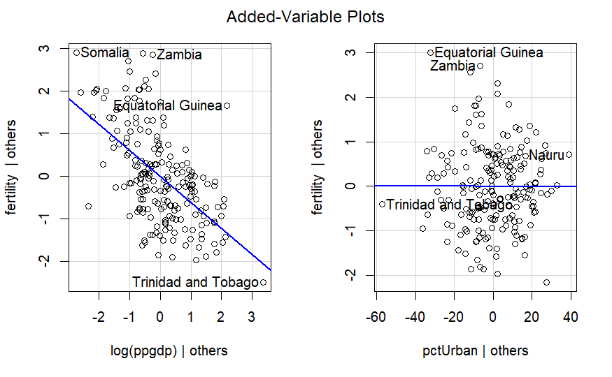

```r
avPlots(fertilityfit)
```

We see that the the pctUrban has a flat slope, meaning it explains hardly any other variations with the other variables in the model taken into account. This agrees with the p-value that we saw.

The next problem we are going to look at transaction data where time will be the response. We will do some data wrangling to look at different combinations of transactions and how they relate to time.

```r
library(car)

Transact$a <- (Transact$t1 + Transact$t2)/2
Transact$d <- Transact$t1 - Transact$t2
head(Transact)
```

|  | t1 | t2 | time | a | d |
| --- | --- | --- | --- | --- | --- |
| 1 | 0 | 1166 | 2396 | 583.0 | -1166 |
| 2 | 0 | 1656 | 2348 | 828.0 | -1656 |
| 3 | 0 | 899 | 2403 | 449.5 | -899 |
| 4 | 516 | 3315 | 13518 | 1915.5 | -2799 |
| 5 | 623 | 3969 | 13437 | 2296.0 | -3346 |
| 6 | 395 | 3087 | 7914 | 1741.0 | -2692 |

```r
summary(Transact)
```

```
       t1               t2            time             a                d
 Min.   :   0.0   Min.   : 148   Min.   :  487   Min.   :  78.5   Min.   :-5315
 1st Qu.:  85.0   1st Qu.:1516   1st Qu.: 3618   1st Qu.: 825.5   1st Qu.:-2825
 Median : 214.0   Median :2192   Median : 5583   Median :1199.5   Median :-1973
 Mean   : 281.2   Mean   :2422   Mean   : 6607   Mean   :1351.5   Mean   :-2140
 3rd Qu.: 437.0   3rd Qu.:3175   3rd Qu.: 8712   3rd Qu.:1763.0   3rd Qu.:-1380
 Max.   :1450.0   Max.   :5791   Max.   :20741   Max.   :3316.5   Max.   : -139
```

So, we went ahead and created two new variables, one is the average of the transaction 1 and 2, and the other is the difference between those same variables. The average is under variable “a” and the difference is under variable “d”. Looking at the summary statistics, it seems as if we may need to so some transformation, but for this purpose we will ignore that for now.

We will start off by fitting four different models to compare using these variables.

```r
firstfit <- lm(time~t1+t2, data=Transact)
summary(firstfit)
```

```
Call:
lm(formula = time ~ t1 + t2, data = Transact)

Residuals:
    Min      1Q  Median      3Q     Max
-4652.4  -601.3     2.4   455.7  5607.4

Coefficients:
             Estimate Std. Error t value Pr(>|t|)
(Intercept) 144.36944  170.54410   0.847    0.398
t1            5.46206    0.43327  12.607   <2e-16 ***
t2            2.03455    0.09434  21.567   <2e-16 ***
---
Signif. codes:  0 ‘***’ 0.001 ‘**’ 0.01 ‘*’ 0.05 ‘.’ 0.1 ‘ ’ 1

Residual standard error: 1143 on 258 degrees of freedom
Multiple R-squared:  0.9091,    Adjusted R-squared:  0.9083
F-statistic:  1289 on 2 and 258 DF,  p-value: < 2.2e-16
```

We see the summary of the model, but before looking into that, let’s go ahead and fit several other models and see what insights they give us.

```r
secondfit <- lm(time~a+d, data=Transact)
summary(secondfit)
```

```
Call:
lm(formula = time ~ a + d, data = Transact)

Residuals:
    Min      1Q  Median      3Q     Max
-4652.4  -601.3     2.4   455.7  5607.4

Coefficients:
            Estimate Std. Error t value Pr(>|t|)
(Intercept) 144.3694   170.5441   0.847    0.398
a             7.4966     0.3654  20.514  < 2e-16 ***
d             1.7138     0.2548   6.726 1.12e-10 ***
---
Signif. codes:  0 ‘***’ 0.001 ‘**’ 0.01 ‘*’ 0.05 ‘.’ 0.1 ‘ ’ 1

Residual standard error: 1143 on 258 degrees of freedom
Multiple R-squared:  0.9091,    Adjusted R-squared:  0.9083
F-statistic:  1289 on 2 and 258 DF,  p-value: < 2.2e-16
```

Next I will use t2 and the d.

```r
thirdfit <- lm(time~t2+d, data=Transact)
summary(thirdfit)
```

```
Call:
lm(formula = time ~ t2 + d, data = Transact)

Residuals:
    Min      1Q  Median      3Q     Max
-4652.4  -601.3     2.4   455.7  5607.4

Coefficients:
            Estimate Std. Error t value Pr(>|t|)
(Intercept) 144.3694   170.5441   0.847    0.398
t2            7.4966     0.3654  20.514   <2e-16 ***
d             5.4621     0.4333  12.607   <2e-16 ***
---
Signif. codes:  0 ‘***’ 0.001 ‘**’ 0.01 ‘*’ 0.05 ‘.’ 0.1 ‘ ’ 1

Residual standard error: 1143 on 258 degrees of freedom
Multiple R-squared:  0.9091,    Adjusted R-squared:  0.9083
F-statistic:  1289 on 2 and 258 DF,  p-value: < 2.2e-16
```

lastly, we will try to fit all of the variables.

```r
fourthfit <- lm(time~., data=Transact)
summary(fourthfit)
```

```
Call:
lm(formula = time ~ ., data = Transact)

Residuals:
    Min      1Q  Median      3Q     Max
-4652.4  -601.3     2.4   455.7  5607.4

Coefficients: (2 not defined because of singularities)
             Estimate Std. Error t value Pr(>|t|)
(Intercept) 144.36944  170.54410   0.847    0.398
t1            5.46206    0.43327  12.607   <2e-16 ***
t2            2.03455    0.09434  21.567   <2e-16 ***
a                  NA         NA      NA       NA
d                  NA         NA      NA       NA
---
Signif. codes:  0 ‘***’ 0.001 ‘**’ 0.01 ‘*’ 0.05 ‘.’ 0.1 ‘ ’ 1

Residual standard error: 1143 on 258 degrees of freedom
Multiple R-squared:  0.9091,    Adjusted R-squared:  0.9083
F-statistic:  1289 on 2 and 258 DF,  p-value: < 2.2e-16
```

We can also compare the coefficients in one table.

```r
compareCoefs(firstfit, secondfit, thirdfit, fourthfit)
```

```
Calls:
1: lm(formula = time ~ t1 + t2, data = Transact)
2: lm(formula = time ~ a + d, data = Transact)
3: lm(formula = time ~ t2 + d, data = Transact)
4: lm(formula = time ~ ., data = Transact)

            Model 1 Model 2 Model 3 Model 4
(Intercept)     144     144     144     144
SE              170     170     170     170

t1            5.462                   5.462
SE            0.433                   0.433

t2           2.0345          7.4966  2.0345
SE           0.0943          0.3654  0.0943

a                     7.497         aliased
SE                    0.365

d                     1.714   5.462 aliased
SE                    0.255   0.433
```

As you can see, there are several variables that have their parameters missing or “aliased” in the fourth model. This is due to some of the variables already being accounted for, especially the ones in which we created that are used in the fourth model. The differences and averages are already captured in the t1 and t2 variables which makes the a and d variables redundant.

For the last demonstration, we are going to use the UN11 data again. This time we will turn the response, fertility, into a log-transformed variable. We are going to use log of ppgdp as well to determine if it describes the relationship well.

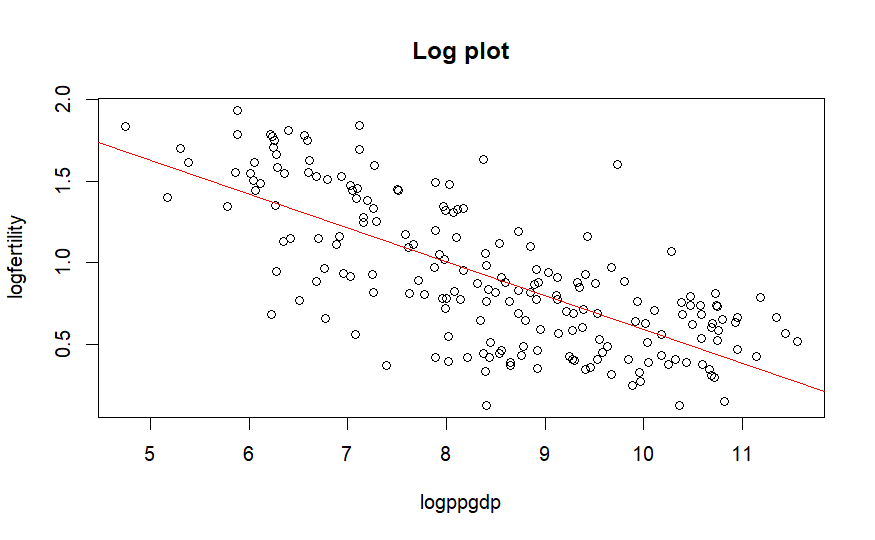

```r
logUN11fit <- lm(log(fertility)~log(ppgdp), data=UN11)
plot(log(UN11$ppgdp), log(UN11$fertility), xlab="logppgdp", ylab="logfertility", main="Log plot")
abline(logUN11fit, col="red")
```

Here we see a negative relationship between the log of fertility and the log of ppgdp. Let’s look at the summary of the fit we just made.

```r
summary(logUN11fit)
```

```
Call:
lm(formula = log(fertility) ~ log(ppgdp), data = UN11)

Residuals:
     Min       1Q   Median       3Q      Max
-0.79828 -0.21639  0.02669  0.23424  0.95596

Coefficients:
            Estimate Std. Error t value Pr(>|t|)
(Intercept)  2.66551    0.12057   22.11   <2e-16 ***
log(ppgdp)  -0.20715    0.01401  -14.79   <2e-16 ***
---
Signif. codes:  0 ‘***’ 0.001 ‘**’ 0.01 ‘*’ 0.05 ‘.’ 0.1 ‘ ’ 1

Residual standard error: 0.3071 on 197 degrees of freedom
Multiple R-squared:  0.526, Adjusted R-squared:  0.5236
F-statistic: 218.6 on 1 and 197 DF,  p-value: < 2.2e-16
```